# Predicting the Method of Exercise

Donald Miller

June 11, 2016

## Introduction

Given the large number of personal devices in use today, a large number of individuals are measuring their behavior. In this project, some of the data gathered by individuals is used to estimate how well they execute five different weight lifting exercises. More information on the data is available here: http://groupware.les.inf.puc-rio.br/har under the Weightlifting section.

## Experimental design

This experiment divides the data into three sets. First there is a training set, used to build the base models which uses 60% of the data. Next there is a validation set, used to train an aggregate model, which uses 20% of the data. Finally, there is a testing set, used to approximate the out-of-sample error, which also represents 20% of the data. This was done by first using createDataPartition to divide the data with a 60/40 split. Then, createDataPartition was used again to split the 40% into to 20% intervals.

## Feature Selection

Model building started by attempting to reduce the number of features used to generate our model. Looking at the NAs in the data, if we remove features that are over 80% NA, we remove all columns with NA. This reduces from 160 columns to 93. We then reduce the columns further by removing all Near Zero Variance columns, leaving 59. Finally we remove the id columns, time stamp columns, and user_name column, leaving 54 columns. We then perform principle component analysis explaining 95% of the variability and end up with 26 features to use to construct our models. However, looking at the first two principle components in the graph below, it will clearly take more dimensions than are easily shown to separate the classes appropriately. While the first two principle components separate the data into five sections, they do not separate it according to the classes.

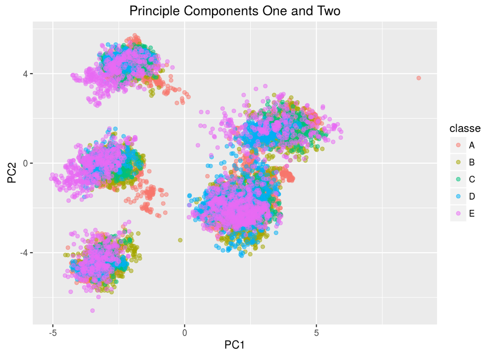

## Cross Validation

Cross Validation is used in two ways. First, Cross Validation is used to generate parameters for two of the models built, the cp value for CART model, resulting in `cp=6e-5`, and the fL and usekernenl values for the Naive Bayesian model, `0` and TRUE respectively. In both cases, 10 fold cross validation was used.

Additionally, Cross Validation is used to generate and compare the models. For each model, 10 fold cross validation was done three times, and the average accuracy was used to determine the relative performance of each model. As can be seen in the figure below, the Random Forest Model is the most accurate.

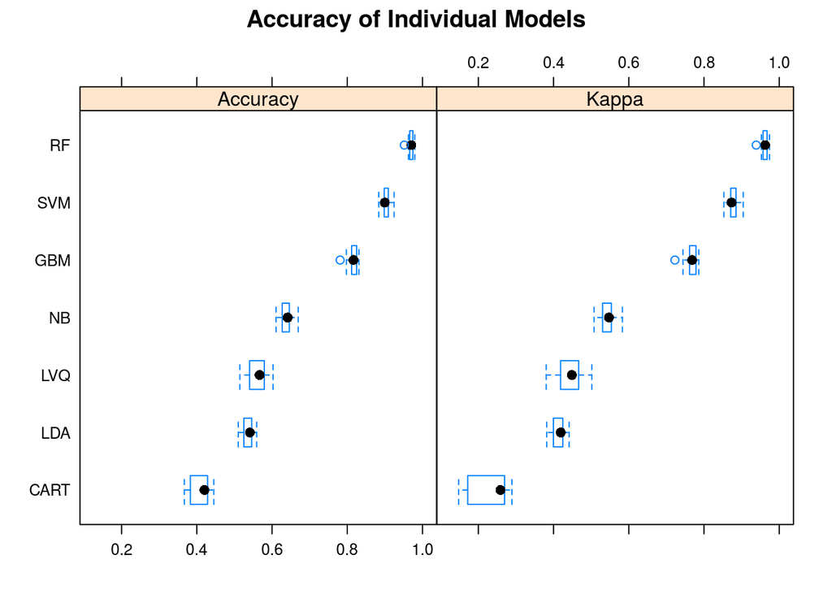

## The Final Model

The final model is generated as a combination of the seven models shown in the above figure. The generated models are:

- Random Forests
- Support Vector Machines
- Generalized Boosting Regression Modeling
- Naive Bayes
- Learning Vector Quantification
- Linear Discriminant Analysis
- CART